# GDi for STEM

### Primjena modela strojnog učenja za predviđanje potražnje

#### Autor: Lucija Josipa Šimić

## Uvod

```
U ovom zadatku ćemo iz podataka o prethodnim narudžbama pokušati napraviti model koji će predviđati potražnju u idućem periodu. Predviđanje potražnje je bitno kako bi mogli bolje preraspodjeliti resurse, radnu snagu i proizvode da uštedimo novac i vrijeme. Ako možemo dobro predvidjeti potražnju, možemo i raspodijeliti sve potrebne resurse da bi maksimizirali efikasnost.
```

## Statistička analiza

Prvo učitavamo potrebne biblioteke.

```python
import numpy as np
import pandas as pd
import matplotlib.pyplot as plt

from sklearn.impute import SimpleImputer
from sklearn.ensemble import RandomForestRegressor
from sklearn.metrics import mean_squared_error as MSE

from itertools import combinations
```

Učitavamo podatke o količini isporučenih proizvoda po danu. Imamo podatke o identifikatoru proizvoda - $ItemId$, datumu narudžbe - $Date$ i o količini isporučenih proizvoda - $Quantity$.

```python
data = pd.read_csv("dataset//task_data.csv", parse_dates=['Date'])
data.head()
```

|  | ItemId | Date | Quantity |
| --- | --- | --- | --- |
| 0 | 0 | 2021-06-22 | 3 |
| 1 | 0 | 2021-06-25 | 6 |
| 2 | 0 | 2021-06-29 | 9 |
| 3 | 0 | 2021-07-01 | 3 |
| 4 | 0 | 2021-07-02 | 3 |

Vidimo da u podatcima imamo 13 067 unosa sa 3 značajke.

```python
data.shape
```

```
(13067, 3)
```

```python
data.describe()
```

|  | ItemId | Quantity |
| --- | --- | --- |
| count | 13067.000000 | 13067.000000 |
| mean | 26.034438 | 95.849468 |
| std | 11.496905 | 123.478688 |
| min | 0.000000 | 1.000000 |
| 25% | 17.000000 | 21.000000 |
| 50% | 27.000000 | 58.000000 |
| 75% | 36.000000 | 108.000000 |
| max | 44.000000 | 1280.000000 |

Provjeravamo ima li u skupu podataka nepostojećih vrijednosti, te vidimo da nema.

```python
data.isnull().sum()
```

```
ItemId      0
Date        0
Quantity    0
dtype: int64
```

U tekstu zadatka piše da za retke koji ne postoje, prodana količina je 0, pa dodajemo te retke u skup podataka, da bi nam skup bio potpun za sve datume.

```python
date1 = '2021-05-05'
date2 = '2022-07-19'

for i in range (1, 44+1):
    for date in pd.date_range(date1, date2).tolist():
        if not ((data['ItemId'] == i) & (data['Date'] == date)).any():
            new_row = {'ItemId':i, 'Date':date, 'Quantity':0}
            data = data.append(new_row, ignore_index=True)
```

Mijenjamo varijablu $Date$ u tip $datetime$ da bi nam bilo lakše baratat s njom i dodajemo u tablicu značajke koje nam govore dodatne stvari o danim datumima.

```python
# mijenjamo date u datetime varijablu
data['Date'] = pd.to_datetime(data['Date'])

# dodajemo značajku dan u mjesecu
data['day'] = data['Date'].dt.day

# dodajemo značajku mjesec
data['month'] = data['Date'].dt.month

# dodajemo značajku godina
data['year'] = data['Date'].dt.year

# dodajemo značajku dan u tjednu
data['dayOfWeek'] = data['Date'].dt.dayofweek

# dodajemo značajku dan u godini
data['dayOfYear'] = data['Date'].dt.dayofyear

# dodajemo značajku tjedan u godini
data['weekOfYear'] = data['Date'].dt.isocalendar().week

# sortiramo podatke prvo po datumu, pa po ID broju proizvoda
# bit će nam korisno kasnije
data = data.sort_values(['Date', 'ItemId'])

data
```

|  | ItemId | Date | Quantity | day | month | year | dayOfWeek | dayOfYear | weekOfYear |
| --- | --- | --- | --- | --- | --- | --- | --- | --- | --- |
| 13067 | 1 | 2021-05-05 | 0 | 5 | 5 | 2021 | 2 | 125 | 18 |
| 13447 | 2 | 2021-05-05 | 0 | 5 | 5 | 2021 | 2 | 125 | 18 |
| 227 | 3 | 2021-05-05 | 118 | 5 | 5 | 2021 | 2 | 125 | 18 |
| 14249 | 4 | 2021-05-05 | 0 | 5 | 5 | 2021 | 2 | 125 | 18 |
| 255 | 5 | 2021-05-05 | 55 | 5 | 5 | 2021 | 2 | 125 | 18 |
| ... | ... | ... | ... | ... | ... | ... | ... | ... | ... |
| 11558 | 40 | 2022-07-19 | 164 | 19 | 7 | 2022 | 1 | 200 | 29 |
| 11935 | 41 | 2022-07-19 | 232 | 19 | 7 | 2022 | 1 | 200 | 29 |
| 12310 | 42 | 2022-07-19 | 403 | 19 | 7 | 2022 | 1 | 200 | 29 |
| 12687 | 43 | 2022-07-19 | 388 | 19 | 7 | 2022 | 1 | 200 | 29 |
| 13066 | 44 | 2022-07-19 | 626 | 19 | 7 | 2022 | 1 | 200 | 29 |

19505 rows × 9 columns

## Vizualizacija podataka

Kako bi mogli nešto više saznati o podacima, podatke ćemo vizualizirati.

Na slici ispod vidimo za sve proizvode količinu naručenog proizvoda po danu. Vidimo da na počeku imamo rupu od mjesec dana u kojoj nema prodanih proizvoda. Također, vidimo da imamo sličan trend kretanja potražnje za većinu proizvoda.

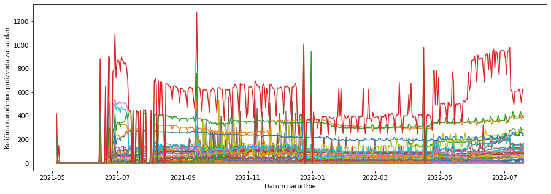

```python
plt.figure(figsize=(15, 5))

plt.xlabel('Datum narudžbe')
plt.ylabel('Količina naručenog proizvoda za taj dan')

for item in range (1, 44+1):
    plt.plot(data[(data['ItemId'] == item)]['Date'], data[(data['ItemId'] == item)]['Quantity'])

plt.show()
```

Na grafu ispod vidimo za 4 proizvoda različitu količinu naručenih proizvoda, ali da svi prate slične trendove kroz vrijeme.

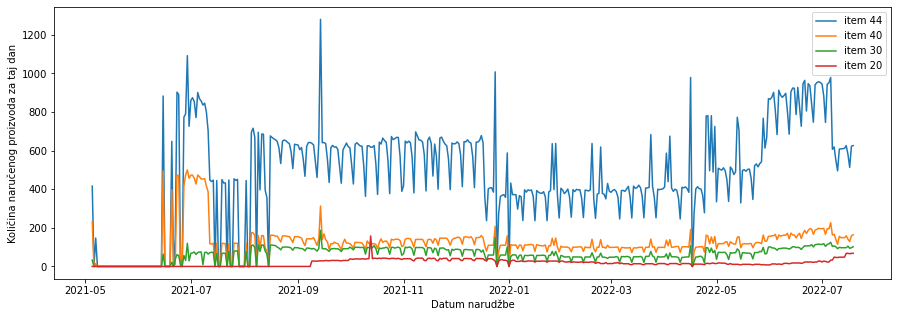

```python
plt.figure(figsize=(15, 5))

plt.xlabel('Datum narudžbe')
plt.ylabel('Količina naručenog proizvoda za taj dan')

plt.plot(data[(data['ItemId'] == 44)]['Date'], data[(data['ItemId'] == 44)]['Quantity'], label='item 44')
plt.plot(data[(data['ItemId'] == 40)]['Date'], data[(data['ItemId'] == 40)]['Quantity'], label='item 40')
plt.plot(data[(data['ItemId'] == 30)]['Date'], data[(data['ItemId'] == 30)]['Quantity'], label='item 30')
plt.plot(data[(data['ItemId'] == 20)]['Date'], data[(data['ItemId'] == 20)]['Quantity'], label='item 20')
plt.legend()
plt.show()
```

Na grafu ispod vidimo da postoji velika razlika između popularnosti različitih proizvoda.

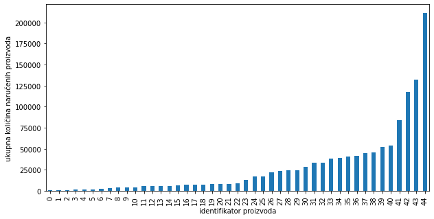

```python
quantityByItem = data.groupby('ItemId').Quantity.sum()

plt.figure(figsize=(10, 5))
quantityByItem.plot.bar()
plt.xlabel('identifikator proizvoda')
plt.ylabel('ukupna količina naručenih proizvoda')

plt.show()
```

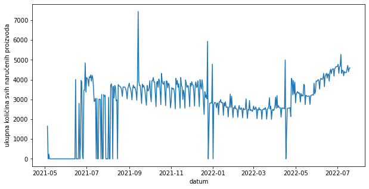

```python
quantityByDate = data.groupby('Date').Quantity.sum()

plt.figure(figsize=(10, 5))
plt.plot(quantityByDate)

plt.xlabel('datum')
plt.ylabel('ukupna količina svih naručenih proizvoda')

plt.show()
```

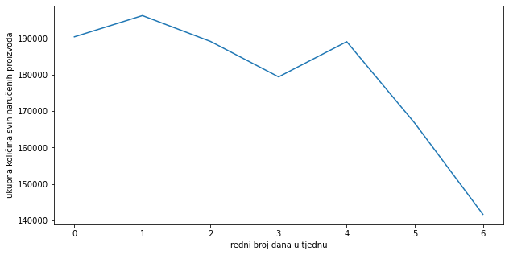

```python
quantityByDayOfWeek = data.groupby('dayOfWeek').Quantity.sum()

plt.figure(figsize=(10, 5))
plt.plot(quantityByDayOfWeek)

plt.xlabel('redni broj dana u tjednu')
plt.ylabel('ukupna količina svih naručenih proizvoda')

plt.show()
```

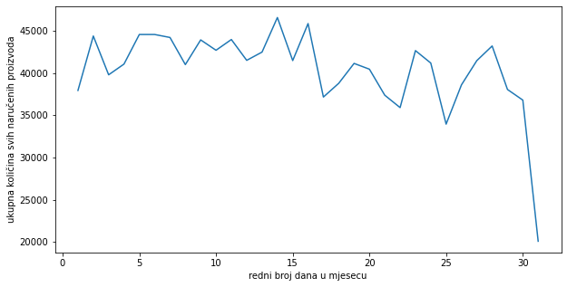

```python
quantityByDayOfMonth = data.groupby('day').Quantity.sum()

plt.figure(figsize=(10, 5))
plt.plot(quantityByDayOfMonth)

plt.xlabel('redni broj dana u mjesecu')
plt.ylabel('ukupna količina svih naručenih proizvoda')

plt.show()
```

## Podijela podataka i dodavanje značajki

Dijelimo podatke na dvije skupine po tekstu zadatka. Za treniranje uzimamo sve narudžbe obavljene prije 20.06.2022 i stavljamo u varijablu $train\_data$, dok za validaciju uzimamo sve nadružbe od 20.06.2022 do 19.07.2022 i stavljamo u varijablu $valid\_data$.

```python
train_data = data[data['Date'] < '2022-06-20'].copy()
valid_data = data[data['Date'] >= '2022-06-20'].copy()
```

Dodajemo u skup podataka za treniranje varijablu $quantityNextDay$ koja označava količinu isporučenih proizvoda idući dan. To će nam nadalje predstavljati varijablu koju želimo predvidjeti.

```python
train_data['quantityNextDay'] = train_data.groupby('ItemId')['Quantity'].shift(-1)
valid_data['quantityNextDay'] = valid_data.groupby('ItemId')['Quantity'].shift(-1)
```

```python
train_data[train_data['ItemId'] == 1].head()
```

|  | ItemId | Date | Quantity | day | month | year | dayOfWeek | dayOfYear | weekOfYear | quantityNextDay |
| --- | --- | --- | --- | --- | --- | --- | --- | --- | --- | --- |
| 13067 | 1 | 2021-05-05 | 0 | 5 | 5 | 2021 | 2 | 125 | 18 | 0.0 |
| 13068 | 1 | 2021-05-06 | 0 | 6 | 5 | 2021 | 3 | 126 | 18 | 0.0 |
| 13069 | 1 | 2021-05-07 | 0 | 7 | 5 | 2021 | 4 | 127 | 18 | 0.0 |
| 13070 | 1 | 2021-05-08 | 0 | 8 | 5 | 2021 | 5 | 128 | 18 | 0.0 |
| 13071 | 1 | 2021-05-09 | 0 | 9 | 5 | 2021 | 6 | 129 | 18 | 0.0 |

Uklanjamo retke koji imaju nepostojeće vrijednosti.

```python
train_data = train_data.dropna()
valid_data = valid_data.dropna()
train_data.head()
```

|  | ItemId | Date | Quantity | day | month | year | dayOfWeek | dayOfYear | weekOfYear | quantityNextDay |
| --- | --- | --- | --- | --- | --- | --- | --- | --- | --- | --- |
| 13067 | 1 | 2021-05-05 | 0 | 5 | 5 | 2021 | 2 | 125 | 18 | 0.0 |
| 13447 | 2 | 2021-05-05 | 0 | 5 | 5 | 2021 | 2 | 125 | 18 | 0.0 |
| 227 | 3 | 2021-05-05 | 118 | 5 | 5 | 2021 | 2 | 125 | 18 | 0.0 |
| 14249 | 4 | 2021-05-05 | 0 | 5 | 5 | 2021 | 2 | 125 | 18 | 0.0 |
| 255 | 5 | 2021-05-05 | 55 | 5 | 5 | 2021 | 2 | 125 | 18 | 0.0 |

Dodajemo u skup podataka za treniranje varijablu $lag\_quantity\_1$ koja označava količinu isporučenih proizvoda prošli dan.

```python
train_data['lag_quantity_1'] = train_data.groupby('ItemId')['Quantity'].shift(1)
valid_data['lag_quantity_1'] = valid_data.groupby('ItemId')['Quantity'].shift(1)
train_data[train_data['ItemId'] == 1].head()
```

|  | ItemId | Date | Quantity | day | month | year | dayOfWeek | dayOfYear | weekOfYear | quantityNextDay | lag_quantity_1 |
| --- | --- | --- | --- | --- | --- | --- | --- | --- | --- | --- | --- |
| 13067 | 1 | 2021-05-05 | 0 | 5 | 5 | 2021 | 2 | 125 | 18 | 0.0 | NaN |
| 13068 | 1 | 2021-05-06 | 0 | 6 | 5 | 2021 | 3 | 126 | 18 | 0.0 | 0.0 |
| 13069 | 1 | 2021-05-07 | 0 | 7 | 5 | 2021 | 4 | 127 | 18 | 0.0 | 0.0 |
| 13070 | 1 | 2021-05-08 | 0 | 8 | 5 | 2021 | 5 | 128 | 18 | 0.0 | 0.0 |
| 13071 | 1 | 2021-05-09 | 0 | 9 | 5 | 2021 | 6 | 129 | 18 | 0.0 | 0.0 |

Dodajemo u skup podataka za treniranje varijablu $diff\_quantity\_1$ koja označava razliku u količinu isporučenih proizvoda između trenutnog i prošlog dana.

```python
train_data['diff_quantity_1'] = train_data.groupby('ItemId')['Quantity'].diff(1)
valid_data['diff_quantity_1'] = valid_data.groupby('ItemId')['Quantity'].diff(1)
train_data[train_data['ItemId'] == 1].head()
```

|  | ItemId | Date | Quantity | day | month | year | dayOfWeek | dayOfYear | weekOfYear | quantityNextDay | lag_quantity_1 | diff_quantity_1 |
| --- | --- | --- | --- | --- | --- | --- | --- | --- | --- | --- | --- | --- |
| 13067 | 1 | 2021-05-05 | 0 | 5 | 5 | 2021 | 2 | 125 | 18 | 0.0 | NaN | NaN |
| 13068 | 1 | 2021-05-06 | 0 | 6 | 5 | 2021 | 3 | 126 | 18 | 0.0 | 0.0 | 0.0 |
| 13069 | 1 | 2021-05-07 | 0 | 7 | 5 | 2021 | 4 | 127 | 18 | 0.0 | 0.0 | 0.0 |
| 13070 | 1 | 2021-05-08 | 0 | 8 | 5 | 2021 | 5 | 128 | 18 | 0.0 | 0.0 | 0.0 |
| 13071 | 1 | 2021-05-09 | 0 | 9 | 5 | 2021 | 6 | 129 | 18 | 0.0 | 0.0 | 0.0 |

Dodajemo u skup podataka za treniranje varijablu $mean\_quantity$ koja označava srednju vrijednost isporučene količine proizvoda u zadnjih 3 dana.

```python
train_data['mean_quantity'] = train_data.groupby('ItemId')['Quantity'].rolling(3).mean().reset_index(level=0,drop=True)
valid_data['mean_quantity'] = valid_data.groupby('ItemId')['Quantity'].rolling(3).mean().reset_index(level=0,drop=True)

train_data[train_data['ItemId'] == 1].tail()
```

|  | ItemId | Date | Quantity | day | month | year | dayOfWeek | dayOfYear | weekOfYear | quantityNextDay | lag_quantity_1 | diff_quantity_1 | mean_quantity |
| --- | --- | --- | --- | --- | --- | --- | --- | --- | --- | --- | --- | --- | --- |
| 13411 | 1 | 2022-06-14 | 0 | 14 | 6 | 2022 | 1 | 165 | 24 | 0.0 | 0.0 | 0.0 | 0.0 |
| 13412 | 1 | 2022-06-15 | 0 | 15 | 6 | 2022 | 2 | 166 | 24 | 0.0 | 0.0 | 0.0 | 0.0 |
| 13413 | 1 | 2022-06-16 | 0 | 16 | 6 | 2022 | 3 | 167 | 24 | 0.0 | 0.0 | 0.0 | 0.0 |
| 13414 | 1 | 2022-06-17 | 0 | 17 | 6 | 2022 | 4 | 168 | 24 | 0.0 | 0.0 | 0.0 | 0.0 |
| 13415 | 1 | 2022-06-18 | 0 | 18 | 6 | 2022 | 5 | 169 | 24 | 0.0 | 0.0 | 0.0 | 0.0 |

```python
valid_data
```

|  | ItemId | Date | Quantity | day | month | year | dayOfWeek | dayOfYear | weekOfYear | quantityNextDay | lag_quantity_1 | diff_quantity_1 | mean_quantity |
| --- | --- | --- | --- | --- | --- | --- | --- | --- | --- | --- | --- | --- | --- |
| 13417 | 1 | 2022-06-20 | 0 | 20 | 6 | 2022 | 0 | 171 | 25 | 0.0 | NaN | NaN | NaN |
| 13793 | 2 | 2022-06-20 | 0 | 20 | 6 | 2022 | 0 | 171 | 25 | 0.0 | NaN | NaN | NaN |
| 14219 | 3 | 2022-06-20 | 0 | 20 | 6 | 2022 | 0 | 171 | 25 | 0.0 | NaN | NaN | NaN |
| 14648 | 4 | 2022-06-20 | 0 | 20 | 6 | 2022 | 0 | 171 | 25 | 0.0 | NaN | NaN | NaN |
| 535 | 5 | 2022-06-20 | 12 | 20 | 6 | 2022 | 0 | 171 | 25 | 17.0 | NaN | NaN | NaN |
| ... | ... | ... | ... | ... | ... | ... | ... | ... | ... | ... | ... | ... | ... |
| 11557 | 40 | 2022-07-18 | 159 | 18 | 7 | 2022 | 0 | 199 | 29 | 164.0 | 129.0 | 30.0 | 143.000000 |
| 11934 | 41 | 2022-07-18 | 232 | 18 | 7 | 2022 | 0 | 199 | 29 | 232.0 | 258.0 | -26.0 | 250.333333 |
| 12309 | 42 | 2022-07-18 | 401 | 18 | 7 | 2022 | 0 | 199 | 29 | 403.0 | 372.0 | 29.0 | 393.666667 |
| 12686 | 43 | 2022-07-18 | 384 | 18 | 7 | 2022 | 0 | 199 | 29 | 388.0 | 414.0 | -30.0 | 411.666667 |
| 13065 | 44 | 2022-07-18 | 623 | 18 | 7 | 2022 | 0 | 199 | 29 | 626.0 | 513.0 | 110.0 | 572.000000 |

1276 rows × 13 columns

## Treniranje modela i evaluacija

Da bi mogli evaluirati koliko nam je dobro rješenje uvodimo bazni primjer. Za to uzimamo primjer kada za idući dan predviđamo da će potražnja biti ista kao za trenutni dan.

```python
y_pred = valid_data['quantityNextDay']
y_true = valid_data['Quantity']

RMSE_baseline = MSE(y_pred, y_true, squared=False)
RMSE_baseline

print('Bazna vrijednost RMSE: {0}'.format(RMSE_baseline))
```

```
Bazna vrijednost RMSE: 20.383490307501006
```

Uzimamo popis značajki koje bi mogle utjecati na količinu potražnje pa ćemo vidjeti koja nam kobinacija značajki daje najmanju pogrešku.

Nad svim ćemo kobinacijama značajki trenirati model slučajnih šuma. Tim modelom ćemo zatim predvidjeti vrijednosti iz skupa za validaciju, te ćemo izračunati RMSE pogrešku i tako pronaći za koje nam je značajke vrijednost pogreške najmanja.

```python
features = ['ItemId', 'Quantity', 'lag_quantity_1', 'diff_quantity_1', 'dayOfWeek', 'mean_quantity', 'day', 'month']
# radimo listu svih kombinacija značajki
list_combinations = list()
for n in range(1, len(features) + 1):
    list_combinations += list(combinations(features, n))
list_combinations = [list(x) for x in list_combinations]
```

```python
# varijable za računanje minimalne pogreške
minErr = 1000
minFeatures = []
minP = []
```

```python
# za svaki skup značajki
for featureList in list_combinations:

    # treniramo model
    imputer = SimpleImputer()
    Xtr = imputer.fit_transform(train_data[featureList])
    ytr = train_data['quantityNextDay']
    mdl = RandomForestRegressor(n_estimators=100, random_state=0, n_jobs=6)
    mdl.fit(Xtr, ytr)

    # radimo predikciju nad skupom podataka za validaciju
    Xval = imputer.transform(valid_data[featureList])
    yval = valid_data['quantityNextDay']
    p = mdl.predict(Xval)

    # računamo pogrešku
    RMSE_model1 = MSE(yval, p, squared=False)

    # print('Features: {0} \nRMSE: {1}\n'.format(featureList, RMSE_model1))

    # ako je pogreška manja od dosad najmanje, ažuriramo vrijednosti najmanje
    if(minErr > RMSE_model1):
        minErr = RMSE_model1
        minFeatures = featureList.copy()
        minP = p.copy()

print('Popis korištenih značajki :\n{0}\n\nnajbolji rezultat RMSE: {1}\n'.format(minFeatures, minErr))
```

```
Popis korištenih značajki :
['ItemId', 'Quantity', 'diff_quantity_1', 'month']

najbolji rezultat RMSE: 32.32272656547921
```

Na grafu ispod smo prikazali stvarni i predviđeni ukupan broj prodanih proizvoda za idući dan. Vidimo da naš model ima sličan oblik kao krivulja stvarnog modela, jedino je broj predviđenih pomaknut za jedan dan unaprijed i oko 600 naručenih proizvoda manje.

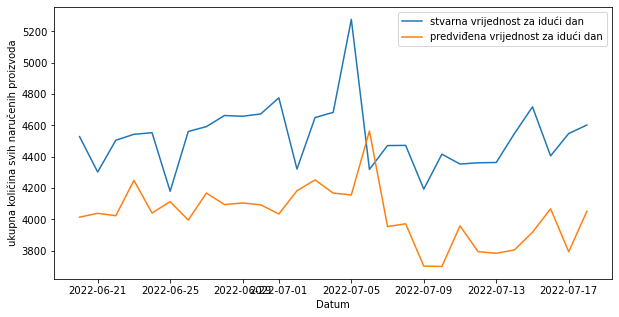

```python
pred = valid_data.copy()
pred['p'] = minP
quantityByDateTrue = pred.groupby('Date').quantityNextDay.sum()
quantityByDatePred = pred.groupby('Date').p.sum()

plt.figure(figsize=(10, 5))
plt.plot(quantityByDateTrue, label='stvarna vrijednost za idući dan')
plt.plot(quantityByDatePred, label='predviđena vrijednost za idući dan')

plt.legend()

plt.xlabel('Datum')
plt.ylabel('ukupna količina svih naručenih proizvoda')

plt.show()
```

## Zaključak

```
Kroz analizu skupa podataka vidjeli smo da postoje uzorci u potražnji različitih proizvoda. Dodali smo dodatne značajke za predviđanje naručenih proizvoda kao što su prosjek naručenih proizvoda u zadnih 3 dana, dan u tjednu, razlika prodaje danas i jučer i slično. Pomoću tih značajki trenirali smo model slučajnih šuma za predviđanje buduće potražnje. Dobili smo da nam najbolje rezultate daje skup značajki ['ItemId', 'Quantity', 'diff_quantity_1', 'month'] sa RMSE: 32.32, što nije bolje od bazne predikcije. Krivulja dobivenog modela je ispala pomaknuta u odnosu na stvarni model. Poboljšanja pretpostavljam da bi mogli dobiti s isprobavanjem različitih modela ili sa dodavanjem još značajki kao što su prosjek prodanih proizvoda taj dan u tjednu ili u tom mjesecu, dodavanjem sezonalnosti i sličnim.
```